# Mini-projet MDI220: Statistique

BARRETO FAÇANHA, Davi

### **EXERCICE 01:**

```r
data(discoveries)

donnees = discoveries
n = length(discoveries)
```

#### **Question 01:**

Nous avons un jeu de données qui montre le nombre de ‘grands’ découvertes scientifiques effectuées, pendant chaque année, entre 1860 et 1959. Compte tenu les variables aléatoires associées $X_{i}$ indépendantes et identiquement distribuées, nous supposons comme première hypothèse arbitraire qu’elle suit la distribution de la densité géométrique:

$$p_{\theta}(x) = \theta(1-\theta)^{x}, x \epsilon N$$

Cependant, nous devons estimer la valeur $\theta$ qui représente le mieux notre distribution. Pour cela, nous allons utiliser la méthode du maximum de vraisemblance. Notre estimateur sera une fonction de $x$, donc,

$$L(x | \theta) = \overset { n }{ \underset { i=1 }{ \prod }} p_{\theta}(x_{i}) = \theta^{n}(1-\theta)^{\sum x}$$

Comme la fonction logarithmique est continue et croissante, maximiser la vraisemblance est la même chose que maximiser son logarithme.

$$L(x | \theta) = n \cdot log(\theta) + log(1-\theta) \cdot \sum{x} \\
\dot {L}(x | \theta) = \frac{n}{\theta} - \frac{\sum{x}}{1 - \theta} = 0 \\
\hat{\theta} = \frac{n}{n + \sum x}$$

```r
var = var(donnees)
sommation = sum(donnees)
moyenne = mean(donnees)

theta = n/(n + sommation)
sprintf('La valeur theta estimée par la vraisemblance: %f', theta)
```

```
## [1] "La valeur theta estimée par la vraisemblance: 0.243902"
```

#### **Question 02:**

Loi de Poisson:

$$P(X = k) = \frac{e^{-\lambda}\lambda^{x}}{x!}$$

D’où $\lambda$ sera notre fréquence moyenne(Esperance):

$$E(X) = \lambda \\
L(x|\theta) = \overset{n}{\underset{i=1}{\prod}} \frac{e^{-\lambda}\lambda^{x}}{x!} = \frac{e^{-n\lambda}\lambda^{\sum x}}{\prod x_{i}!}$$

Appliquant également le logarithme et la derivation,

$$L(x|\theta) = -n\lambda +log(\lambda)\sum x -\sum x \\
\dot {L}(x | \theta) = \frac{\sum x}{\lambda} - n = 0$$

Enfin, on trouve le paramètre pour notre hypothèse de Poisson:

$$\hat{\lambda} = \frac{\sum x}{n}$$

```r
lamb = sommation/n
sprintf('La valeur lambda estimée par la vraisemblance: %f', lamb)
```

```
## [1] "La valeur lambda estimée par la vraisemblance: 3.100000"
```

#### **Question 03:**

#### **Loi Geometrique:**

Par Definition, l’Esperance theorique sera :
$$E[X] = \frac{1 - \hat{\theta}}{\hat{\theta}} \quad Var[X] = \frac{1 - \hat{\theta}}{\hat{\theta}^2}$$

Pour cette raison,

```r
espTheorGeo = (1-theta)/theta
varTheorGeo = (1-theta)/theta^2
sprintf('L\'Esperance Theorique pour la Loi Geometrique : %f', espTheorGeo)
```

```
## [1] "L'Esperance Theorique pour la Loi Geometrique : 3.100000"
```

```r
sprintf('L\'Esperance Empirique des donnees : %f', moyenne)
```

```
## [1] "L'Esperance Empirique des donnees : 3.100000"
```

```r
sprintf('La Variance Theorique pour la Loi Geometrique : %f', varTheorGeo)
```

```
## [1] "La Variance Theorique pour la Loi Geometrique : 12.710000"
```

```r
sprintf('La Variance Empirique des donnees : %f', var)
```

```
## [1] "La Variance Empirique des donnees : 5.080808"
```

#### **Loi de Poisson:**

Par Definition, l’Esperance theorique sera :

$$E[X] = Var[X] = \lambda$$

Pour cette raison,

```r
espTheorPois = lamb
varTheorPois = lamb
sprintf('L\'Esperance Theorique pour la Loi Geometrique : %f', espTheorPois)
```

```
## [1] "L'Esperance Theorique pour la Loi Geometrique : 3.100000"
```

```r
sprintf('L\'Esperance Empirique des donnees : %f', moyenne)
```

```
## [1] "L'Esperance Empirique des donnees : 3.100000"
```

```r
sprintf('La Variance Theorique pour la Loi Geometrique : %f', varTheorPois)
```

```
## [1] "La Variance Theorique pour la Loi Geometrique : 3.100000"
```

```r
sprintf('La Variance Empirique des donnees : %f', var)
```

```
## [1] "La Variance Empirique des donnees : 5.080808"
```

#### **Question 04:**

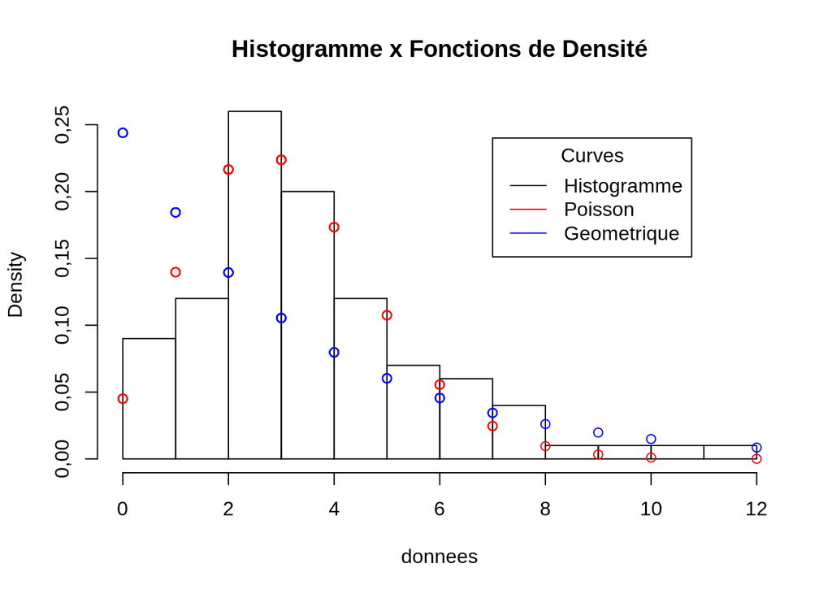

```r
# Plot Loi Geométrique
yGeom = dgeom(donnees, theta)
# Plot Loi de Poisson
yPois = dpois(donnees, lamb)

# Histograma avec chaq'une des lois.
h = hist(donnees, right = F, probability=TRUE, main="Histogramme x Fonctions de Densité", breaks = 13)
  lines(donnees[0:100], yPois, col = 'red', type='p')
  lines(donnees[0:100], yGeom, col = 'blue', type='p')
  legend(7, 0.24, legend=c("Histogramme", "Poisson", "Geometrique"), col=c("black", "red", "blue"), lty=1:1, title= "Curves")
```

#### **Question 05:**

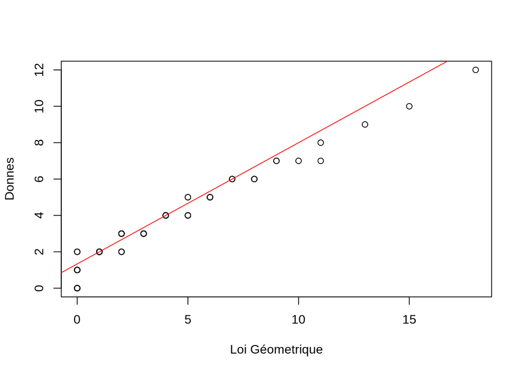

```r
# QQ-PLOT - Loi Geométrique
qGeom = qgeom(ppoints(n), theta)
qqplot(qGeom, donnees, xlab = 'Loi Géometrique', ylab = 'Donnes')
qqline(donnees, distribution = function(x) qgeom(x, theta), col='red')
```

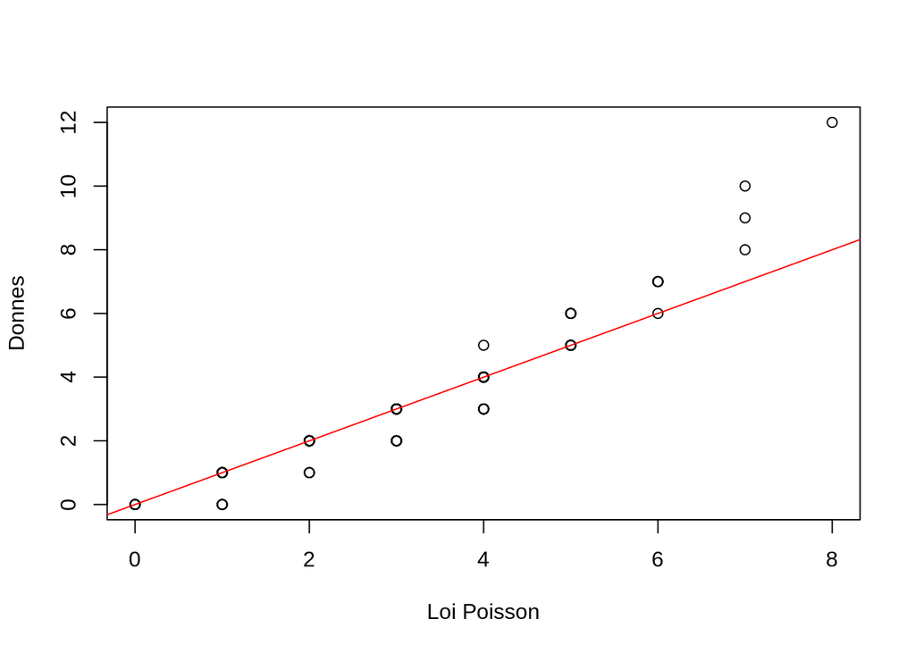

```r
#QQ-PLOT - Loi de Poisson
qPois = qpois(ppoints(n), lamb)
qqplot(qPois, donnees, xlab = 'Loi Poisson', ylab = 'Donnes')
qqline(donnees, distribution = function(x) qpois(x, lamb), col ='red')
```

En analysant ces deux graphiques, il est possible de voir que la Distribution de Poisson a atteint des valeurs plus proches de la diagonale que la Distribution de Geometrique.

#### **Question 06:**

Pour $j \in \{1, ... ,k\}$, soit $n_j = |\{ i:Xi\in Ij \}|$

$$Pour \space j \in \{1, ... ,k\}, soit \space n_j = |\{ i:Xi\in Ij \}| \\
avec \\
I = \{ \{0 \}, \{1 \}, \{2 \}, \{3 \}, \{4 \}, \{5,+\infty) \}\} \\
où \\
p_{1,...,5} = P(X \in I_j) = P(X = j) \\
p_6 = P(X \in I_6) = P(X >= 5) = 1 - \sum_{j =1}^{5}{p_j}$$

C’est-à-dire que le vecteru $n_j$ va garder les frequences de l’histogramme pour que on puisse calculer la probabilité suivant les définitions de la question.

```r
# Vecteur de probabilités p_j pour la Loi Geometrique
pj_Init = dgeom(seq(0,4,1), theta)
probComplementaire = 1 - sum(pj_Init)
pj_Geom = c(pj_Init, probComplementaire)

# Vecteur de probabilités p_j pour la Loi de Poisson
pj_Init = dpois(seq(0,4,1), lamb)
probComplementaire = 1 - sum(pj_Init)
pj_Pois = c(pj_Init, probComplementaire)

# Vecteur de frequences I_j
freqs = h$counts

nj = freqs[1:5]
aux = sum(freqs[6:length(freqs)])
nj = c(nj, aux)
```

La fonction Statistique est definie comme suit:

```r
#Trouver le Statistique
Stat_Geom = 0;
Stat_Poisson = 0;

# Statistique Geometrique
for (j in 1:6) {
  Stat_Geom = Stat_Geom + ((nj[j] - n*pj_Geom[j])^2)/(n*pj_Geom[j])
}

# Statistique de Poisson
for (j in 1:6) {
  Stat_Poisson = Stat_Poisson + ((nj[j] - n*pj_Pois[j])^2)/(n*pj_Pois[j])
}
```

La statistique $S$ ci-dessus suit une loi du $\chi^2$(chi-2) à $k−1−p$ degrés de liberté, où $p$ est le nombre de paramètres de notre loi de distribuition. Donc, la Statistique a 4 degrés de liberté.

```r
## Degrees de liberte
# S ci-dessus suit une loi du χ 2 (chi-2) à k − 1 − p degrés de liberté.
DegreeLiberte = 6 -1 -1

# P-valeur pour la loi Geometrique
pValeur = pchisq(Stat_Geom, DegreeLiberte)
pValeur_Geom = 1 - pValeur

# P-valeur pour la loi de Poisson
pValeur = pchisq(Stat_Poisson, DegreeLiberte)
pValeur_Poisson = 1 - pValeur

## Quantile
confiance = 1 - 0.05
qntl = qchisq(confiance, DegreeLiberte)
```

### **EXERCICE 02:**

#### **Question 01:**

Tout d’abord, on a besoin de démontrer que $P_{\lambda}(\sum{X_{i}} \ge s) \space \forall s \ge 1$. Donc,

$$P_{\lambda}(\sum{X_{i}} \ge s) = 1 - \sum_{k=0}^{s-1}{\frac{(nk)^k exp[-nk]}{k!}}$$
La fonction de densité est discrète dans $x$ mais constante dans $\lambda$. Par conséquent, on dérive par rapport à $\lambda$ et vérifions que sa dérivée est toujours $\ge 0$. Supposons $P_{\lambda}(\sum{X_{i}} \ge s)$ comme $f(\lambda)$.

$$\frac{\partial f(\lambda)}{\partial \lambda} = -\frac{\partial}{\partial \lambda} \sum_{k=0}^{s-1}{\frac{(nk)^k exp[-nk]}{k!}} = \sum_{k=0}^{s-1}{\frac{n^{k+1}\lambda^{k}exp[-nk]}{k!}} - \sum_{k=0}^{s-1}{\frac{n^{k}\lambda^{k-1}exp[-nk]}{(k-1)!}}
\\
= \sum_{u=1}^{s}{\frac{n^{u}\lambda^{u-1}exp[-nk]}{(u-1)!}} - \sum_{k=0}^{s-1}{\frac{n^{k}\lambda^{k-1}exp[-nk]}{(k-1)!}}
\\
= \frac{n^{s}\lambda^{s-1}exp[-nk]}{(s-1)!} \ge 0 \rightarrow Toujours \space Croissante$$

#### **Question 02:**

$$\text{Notre fonction Statistique est définie par,}\\
T = \sum_{i=1}^{n}{X_i} \quad avec \quad \delta(T) = 1\{T > s\} \\$$

$$\text{D'une façon que, } \\
X \sim Poisson(\lambda) \\
T \sim Poisson(n\lambda) \\$$
$$\text{Avec cela, on définit nos hypothèses} \\
H_{ 0 }:\lambda \le 3 \quad
H_1: \lambda > 3 \\$$

$$\text{On sait aussi que:} \\
\alpha =sup(E_{ n\lambda }(\delta (T)))=P_{ n\lambda }(T>s)\quad ; { pour \space \lambda =3 }\\
\text{Néanmoins}\\
P_{ 3n }(T>s)\le 0.05 \rightarrow P_{ 3n }(T\le s)>0.95$$
Appliquent la fonction de quantille du R, on trouve $s = 329$, c’est-à-dire, $T < s$.

```r
s = qpois(0.95, n*3)
sprintf('La valeur du s = %i', s)
```

```
## [1] "La valeur du s = 329"
```

#### **Question 03:**

Enfin, on accept la Hypothèse Nulle pour $T<s$.

#### **Question 04:**

$$m = \frac{1}{n}\sum_{i=1}^{n}{x_i} \quad et \quad T = \sum_{i=1}^{n}{x_i} \\
Donc, \space T = n\cdot m$$
Toutefois, la moyenne est fixée. Alors,
$$T = 3.1 \cdot n$$

De cette manière, on augmente $n$ jusqu’au moment que le T soit plus grand que le quantille du $qpois()$ appliqué par $\lambda' = n\lambda$. Lorsque la condition est atteinte, nous arrêtons l’itération et vérifions dans quelle valeur de données elle s’est arrêtée.

```r
m = moyenne
j = 0;

while (m*j <= qpois(0.95,j*3)){
  j = j + 1
}
sprintf('La valeur n0 trouvée était: %d', j)
```

```
## [1] "La valeur n0 trouvée était: 811"
```

C’est-à-dire, on aurait besoin de 811 données pour pouvoir rejeter $H_0$.

#### **Question 05:**

Pour la fonction de Puissance:
$$\beta(\lambda) = 1 - P_{\lambda}[\text{accepter à tort $H_0$}] \quad et \quad \lambda \in (3,4]$$
On peut plotter un graphique du comportement de la Fonction Puissance.

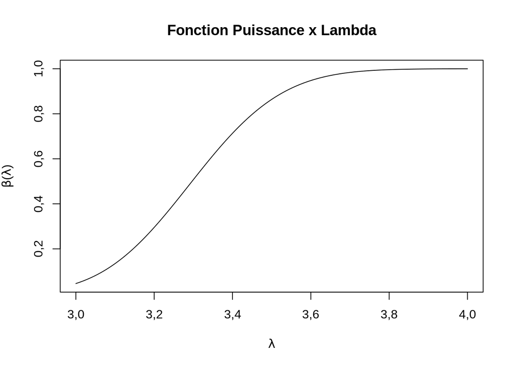

```r
# Les lambdas de l'intervalle fixé
vecteurLambda = 100*seq(3.000001, 4, 0.000001)

# La Puissance Beta definie
betaLambda = 1 - ppois(s, lambda = vecteurLambda)

plot(vecteurLambda/100 , betaLambda, main = 'Fonction Puissance x Lambda', type = 'l', xlab = expression(lambda) , ylab = expression(paste(beta, '(',lambda, ')')))
```

On définit une intervalle de plotter et fait une interaction qui augmente la quantité de données jusqu’à ce que la puissance devienne plus grande que $0.9$.

```r
s_aux = s;
n_aux = 100

# Trouver la condition de probabilité
while (1 - ppois(s_aux, lambda = 3.5*n_aux) < 0.9) {
  n_aux = n_aux + 1
  s_aux = qpois(0.95, lambda = 3*n_aux)
}

sprintf('On a trouvé un minimum de %i donnees', n_aux)
```

```
## [1] "On a trouvé un minimum de 112 donnees"
```

### **EXERCICE 03**

#### **Question 01:**

La loi conjuguée de Poisson, pour la notre loi a priori, est la distribuition Gamma. De cette façon,

$$\pi(\lambda) \sim Gamma(\lambda, \theta, k) \\
Gamma(\lambda, \theta, k) = \frac{x^{k-1}exp[-\frac{\lambda}{\theta}]}{\Gamma(k)\theta^{k}}$$

Pour les distributions Gamma des paramètres $\theta$ et $k$, on a que:

$$E_{\pi}(\lambda) = k\theta = 5 \\
Var_{\pi}(\lambda) = 100 = k\theta^2$$

En résolvant ce système simple, on trouve $\theta = 20$ et $k = 0.25$.

Finalement,
$$\pi(\lambda) = \frac{x^{-\frac{3}{4}}exp[-\frac{\lambda}{20}]}{\Gamma(\frac{1}{4})20^{\frac{1}{4}}}$$

```r
kGamma = 0.25
thetaGamma = 20
yGamma = dgamma(donnees, shape = kGamma, scale = thetaGamma)
```

#### **Exercice 02:**

Par definition, la loi a posteriori suivra la loi Gamma aussi. On calcule la lois a posteriori comme suit,

$$\pi(\lambda | X) = \frac {P_{\theta}(X)\pi(\lambda)}{ \int _{\Theta}{P_{\lambda'}(X)\pi(\lambda')}\mu(d\lambda')}$$

Pour faciliter la compréhension, calculons d’abord seulement le marginal, c’est-à-dire, le dénominateur.

$$m( \lambda' ) = \int_{0}^{\inf}{ \frac{\lambda^{\sum{x}} exp[-n\lambda]}{ \prod_{1}^{n}{x_i !}}} \frac{\lambda^{k-1} exp[-\frac{\lambda}{\theta}]}{\Gamma(k)\theta^k}
\\
= \frac{1}{\prod_{1}^{n}{x_i !} \Gamma(k)\theta^k} \int_{0}^{\inf}{\lambda^{\sum{x} + k - 1}exp[-n\lambda - \frac{\lambda}{\theta}]}d\lambda$$

Appelant $u = n\lambda + \frac{\lambda}{\theta}$, on résout l’intégrale par la méthode de la substitution.

$$= \frac{1}{\prod_{1}^{n}{x_i !} \Gamma(k)\theta^k} \frac{1}{(n + \frac{1}{\theta})^{\sum{x} + k}} \int_{0}^{\inf}{u^{\sum{x} + k - 1} exp[-u]}du$$

Par la definition de fonction Gamma trouvé ci-dessous, on peut récrire l’integrale comme une fonction gamma, plus en bas.

$$\Gamma : z \mapsto \int_0^{+\infty} t^{z-1}\,e^{-t}\,\mathrm{d}t \\
m(\lambda | X) = \frac{\Gamma(\sum{x} + k)}{\prod_{1}^{n}{x_i !} \Gamma(k)\theta^k (n + \frac{1}{\theta})^{\sum{x} + k}}$$

Enfin, on fait la substitution sur l’équation générale. Ce faisant, on a

$$\pi(\lambda | X) = \frac {\lambda^{\sum{x}}exp[-n\lambda] \lambda^{k-1}exp[-\frac{\lambda}{\theta}]}{\prod_{1}^{n}{ x_{i}!} \Gamma(k)\theta^{k}} \frac{(\prod_{1}^{n}{ x_{i}!)} \Gamma(k)\theta^{k}}{\Gamma(\sum{x} + k)} (\frac{1}{\theta} + n)^{\sum{x} + k}
\\
\pi(\lambda | X) = \frac{\lambda^{\sum{x}+k-1}exp[-n\lambda - \frac{\lambda}{\theta}]}{\Gamma(\sum{x} + k)} \frac{1}{ \frac{1}{(\frac{1}{\theta} + n)^{\sum{x} + k}}}
\\
\pi(\lambda | X) \sim Gamma(\lambda, \theta', k')$$
Finalement, on arrive aux nos nouveaux paramètres.
$$\theta' = \frac{\theta}{n\theta + 1} \quad et \quad k' = \sum_{i=1}^{n}{x_i} + k$$

L’Esperance du estimateur a posteriori é donnée par:

$$E_{\pi}(\lambda | X) = \int_{\Theta}{\lambda'}\pi(\lambda')d\lambda'
\\
E_{\pi}(\lambda | X) = \frac{1}{\Gamma(k')\theta'^{k'}} \int_{0}^{\inf}{\lambda'}^{k'}exp[-\frac{\lambda'}{\theta'}]d\lambda'
\\$$

Si on fait l’intégration par substitution avec $u = \frac{\lambda'}{\theta'}$, l’equation devient:

$$\frac{\theta^{k'+1}}{\Gamma(k')\theta'^{k'}} \int_{0}^{\inf}{u^{k'+1 -1}}exp[-u]du$$

Cependant,

$$\Gamma(z+1)=z \; \Gamma(z)$$
Par conséquent,

$$E_{\pi}(\lambda | X) = \frac{\Gamma(k' + 1)}{\Gamma(k')}\theta' = \frac{\Gamma(k')k'}{\Gamma(k')}\theta' = k'\theta'$$

Étant $k'$ et $\theta'$ les paramètres que on a trouvé dans la question 3.2, on a:

$$k'\theta' = (\sum{x} + k)(\frac{\theta}{n\theta + 1})$$

Pour que on puisse faire une analyse quanlitative de l’équation de l’esperance, il est important de faire une petite manipulation algébrique. On réécrive les équations comme:

$$k'\theta' = (\sum_{i = 0}^{n}{x} + k)(\frac{1}{\frac{1}{\theta} + n})$$
Si on applique la limite à l’infini, on vois que l’Esperance a posteriori sera la même que de l’estimateur de vraisemblance de Poisson. Les valeurs de $k$ et $\theta$ sont négligeables.
$$lim_{n \rightarrow \inf}[(\sum_{i = 0}^{n}{x_i} + k)(\frac{1}{\frac{1}{\theta} + n})] = \frac{\sum_{i = 0}^{n}{x_i}}{n} = \hat{\lambda}$$

#### **Exercice 03:**

Après tout qu’on a vu, on calcule:

$$\theta' = 0,009995002 \\
k' = 310.25 \\
E_{\pi}(\lambda | X) \cong 3.10095$$

#### **Exercice 04:**

Pour,
$$P(\lambda \in I_{|x_{i:n}}) \ge \alpha$$
On a un intervalle de credibilité donné par:

$$I = [\frac{1 - \alpha}{2}, \frac{1 + \alpha}{2}] = [0.025, 0.975]$$

```r
kPos = sommation + kGamma
thetaPos = thetaGamma/(length(discoveries)*thetaGamma + 1)

intervalle <- c(0.025, 0.975)
qgamma(intervalle, shape = kPos, scale = thetaPos)
```

```
## [1] 2,765458 3,455370
```